# Bayesian Robust Linear Regression with Outlier Detection

*A minimal reproducable example of Robust Regression with Outlier Detection using PyMC3.*

[figure not shown]

**Jonathan Sedar**  
Consulting Data Scientist  
Applied AI Ltd

@jonsedar  
applied.ai

[figure not shown]

## Originally developed for the PyMC3 examples

[PyMC3](http://pymc-devs.github.io/pymc3/) is a fairly new library to perform MCMC in pure Python.

- Open source and under active development.
- A comprehensive package of symbolic statistical modelling syntax and very efficient gradient-based samplers using the Theano library (of deep-learning fame).
- Includes the Non U-Turn Sampler (NUTS) developed recently by Hoffman & Gelman in 2014, which is only otherwise available in STAN.

Note: this presentation is made using RISE, an in-development project to display a live Jupyter Notebook in reveal.js presentation form.

*Let me know if you notice anything buggy.*

## A method for Robust Regression

- This method returns a robust estimate of linear coefficients and an indication of which datapoints (if any) are outliers.
- The dataset is tiny and hardcoded into this Notebook. It contains errors in both the x and y, but we will deal here with only errors in y.
- This is a complementary approach to the Student-T robust regression as illustrated in Thomas Wiecki's notebook in the [PyMC3 documentation](http://pymc-devs.github.io/pymc3/GLM-robust/), that approach is also compared here.
- The likelihood evaluation is essentially a copy of eqn 17 in "Data analysis recipes: Fitting a model to data" - [Hogg 2010](http://arxiv.org/abs/1008.4686).
- The model is adapted specifically from Jake Vanderplas' [implementation](http://www.astroml.org/book_figures/chapter8/fig_outlier_rejection.html) (3rd model tested).

# Setup

```python
import numpy as np
import pandas as pd
import matplotlib.pyplot as plt
import seaborn as sns

from scipy import optimize
import pymc3 as pm
import theano as thno
import theano.tensor as T

# configure some basic options
sns.set(style="darkgrid", palette="muted")
pd.set_option('display.notebook_repr_html', True)
plt.rcParams['figure.figsize'] = 12, 8
np.random.seed(0)
```

## Load and Prepare Data

We'll use the Hogg 2010 data available at https://github.com/astroML/astroML/blob/master/astroML/datasets/hogg2010test.py

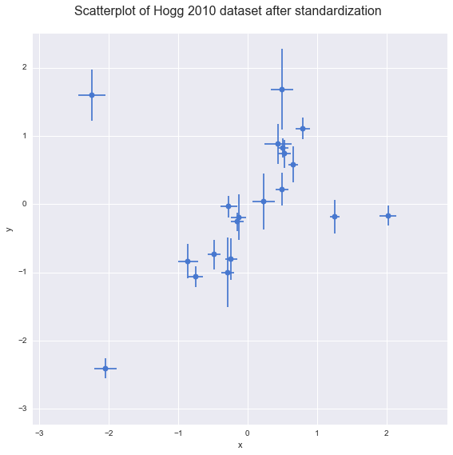

```python
plot_data(dfhoggs, xlims, ylims)
```

# Conventional OLS Model in PyMC3

##### A really simple, conventional model stated in Frequentist syntax:

$$\bf{y} = \beta^{T} \bf{x} + \bf{\epsilon}$$

... where for datapoint $i \in n$:

- $y_{i}$ = output feature value
- $x_{i}$ = input feature values dimension $j$
- $\beta$ = coefs = $[1, \beta_{j}]$
- $\epsilon_{i} \sim N(0,\sigma^2)$ = indep. Gaussian noise

##### Stated slightly differently in a Bayesian syntax:

$$\bf{y} \sim \mathcal{N}(\beta^{T} \bf{x},\sigma^{2})$$

... where for datapoint $i \in n$:

- $y_{i}$ is a sample from a
- $\mathcal{N}$ormal distribution defined by:
  - mean $\mu = \beta^{T} x_{i}$ and
  - variance $\sigma^{2}$

##### Quick reminder: Bayesian inference

$$p(\theta|X) \propto p(X|\theta) p(\theta)$$

In order to learn the correct values (or more properly, the distributions) for $\theta$ we need to evaluate the *posterior predictive distribution* for values $y$

In the continuous case, this takes the form:

$$p(y|X) = \int_{\theta} p(\theta|X) p(y|\theta) d\theta$$

Integration is hard! So we sample...

##### Define model

```python
with pm.Model() as mdl_ols:

    ## Define weakly informative Normal priors to give Ridge regression
    b0 = pm.Normal('b0_intercept', mu=0, sd=100)
    b1 = pm.Normal('b1_slope', mu=0, sd=100)

    ## Define linear model
    yest = b0 + b1 * dfhoggs['x']

    ## Use y error from dataset, convert into theano variable
    sigma_y = thno.shared(np.asarray(dfhoggs['sigma_y'],
                            dtype=thno.config.floatX), name='sigma_y')

    ## Define Normal likelihood
    likelihood = pm.Normal('likelihood', mu=yest, sd=sigma_y
                           ,observed=dfhoggs['y'])
```

##### Sample

```python
with mdl_ols:

    ## find MAP using Powell, seems to be more robust
    start_MAP = pm.find_MAP(fmin=optimize.fmin_powell, disp=True)

    ## take samples
    trc_ols = pm.sample(2000, start=start_MAP, step=pm.NUTS())
```

```
Optimization terminated successfully.
         Current function value: 145.777745
         Iterations: 3
         Function evaluations: 118
 [-----------------100%-----------------] 2000 of 2000 complete in 0.7 sec
```

##### View Traces

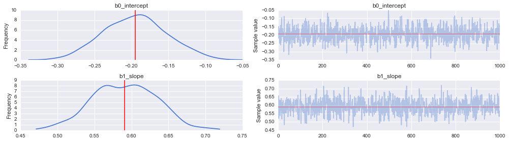

```python
_ = pm.traceplot(trc_ols[-1000:], figsize=(14,len(trc_ols.varnames)*2)
    ,lines={k: v['mean'] for k, v in pm.df_summary(trc_ols[-1000:]).iterrows()})
```

# Create Robust Model: Student-T Method

- Instead of using a Normal distribution for the likelihood, we use a Student-T, which has fatter tails.
- In theory this allows outliers to have a smaller MSE in the likelihood, and thus less influence on the regression.
- This method does not produce inlier / outlier flags but is simple and very quick run so a comparison seems worthwhile.

**Note:** we'll constrain the Student-T 'degrees of freedom' parameter `nu` to be an integer, but otherwise leave it as just another stochastic to be inferred: no need for prior knowledge.

##### Define Model

```python
with pm.Model() as mdl_studentt:

    ## Define weakly informative Normal priors to give Ridge regression
    b0 = pm.Normal('b0_intercept', mu=0, sd=100)
    b1 = pm.Normal('b1_slope', mu=0, sd=100)

    ## Define linear model
    yest = b0 + b1 * dfhoggs['x']

    ## Use y error from dataset, convert into theano variable
    sigma_y = thno.shared(np.asarray(dfhoggs['sigma_y'],
                            dtype=thno.config.floatX), name='sigma_y')

    ## define prior for Student T degrees of freedom
    nu = pm.DiscreteUniform('nu', lower=1, upper=100)

    ## Define Student T likelihood
    likelihood = pm.StudentT('likelihood', mu=yest, sd=sigma_y, nu=nu
                           ,observed=dfhoggs['y'])
```

##### Sample

```python
with mdl_studentt:

    ## find MAP using Powell, seems to be more robust
    start_MAP = pm.find_MAP(fmin=optimize.fmin_powell, disp=True)

    ## two-step sampling to allow Metropolis for nu (which is discrete)
    step1 = pm.NUTS([b0, b1])
    step2 = pm.Metropolis([nu])

    ## take samples
    trc_studentt = pm.sample(2000, start=start_MAP, step=[step1, step2])
```

```
Optimization terminated successfully.
         Current function value: 107.488021
         Iterations: 3
         Function evaluations: 77
 [-----------------100%-----------------] 2000 of 2000 complete in 1.1 sec
```

##### View Traces

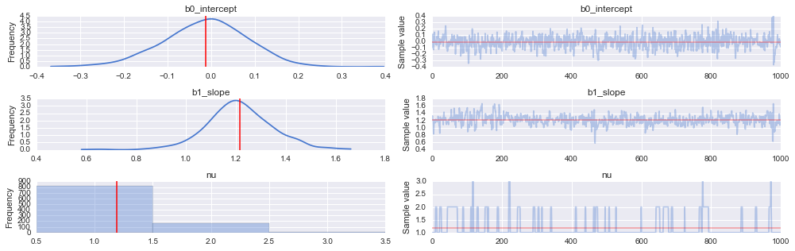

```python
_ = pm.traceplot(trc_studentt[-1000:], figsize=(14,len(trc_studentt.varnames)*1.5)
    ,lines={k: v['mean'] for k, v in pm.df_summary(trc_studentt[-1000:]).iterrows()})
```

# Create Robust Model with Outliers: Hogg Method

General idea:

- create a 'mixture' model whereby datapoints can be described by either the linear model (inliers) or a modified linear model with different mean and larger variance (outliers).
- The likelihood is evaluated over a mixture of two likelihoods, one for 'inliers', one for 'outliers'.

Hogg 2010 and Jake Vanderplas' code have more complete information about the modelling technique.

- A Bernouilli distribution is used to randomly assign datapoints in N to either the inlier or outlier groups, and we sample the model as usual to infer robust model parameters and inlier / outlier flags:

$$ \mathcal{logL} = \sum_{i}^{i=N} log \left[ \frac{(1 - B_{i})}{\sqrt{2 \pi \sigma_{in}^{2}}} exp \left( - \frac{(x_{i} - \mu_{in})^{2}}{2\sigma_{in}^{2}} \right) \right] + \sum_{i}^{i=N} log \left[ \frac{B_{i}}{\sqrt{2 \pi (\sigma_{in}^{2} + \sigma_{out}^{2})}} exp \left( - \frac{(x_{i}- \mu_{out})^{2}}{2(\sigma_{in}^{2} + \sigma_{out}^{2})} \right) \right] $$

... where:  
$\bf{B}$ is Bernoulli-distibuted $B_{i} \in [0_{(inlier)},1_{(outlier)}]$

```python
def logp_signoise(yobs, is_outlier, yest_in, sigma_y_in, yest_out, sigma_y_out):
    '''
    Define custom loglikelihood for inliers vs outliers.
    NOTE: in this particular case we don't need to use theano's @as_op
    decorator because (as stated by Twiecki in conversation) that's only
    required if the likelihood cannot be expressed as a theano expression.
    We also now get the gradient computation for free.
    '''

    # likelihood for inliers
    pdfs_in = T.exp(-(yobs - yest_in + 1e-4)**2 / (2 * sigma_y_in**2))
    pdfs_in /= T.sqrt(2 * np.pi * sigma_y_in**2)
    logL_in = T.sum(T.log(pdfs_in) * (1 - is_outlier))

    # likelihood for outliers
    pdfs_out = T.exp(-(yobs - yest_out + 1e-4)**2 / (2 * (sigma_y_in**2 + sigma_y_out**2)))
    pdfs_out /= T.sqrt(2 * np.pi * (sigma_y_in**2 + sigma_y_out**2))
    logL_out = T.sum(T.log(pdfs_out) * is_outlier)

    return logL_in + logL_out
```

##### Define model

```python
with pm.Model() as mdl_signoise:

    ## Define weakly informative Normal priors to give Ridge regression
    b0 = pm.Normal('b0_intercept', mu=0, sd=100)
    b1 = pm.Normal('b1_slope', mu=0, sd=100)

    ## Define linear model
    yest_in = b0 + b1 * dfhoggs['x']

    ## Define weakly informative priors for the mean and variance of outliers
    yest_out = pm.Normal('yest_out', mu=0, sd=100)
    sigma_y_out = pm.HalfNormal('sigma_y_out', sd=100)

    ## Define Bernoulli inlier / outlier flags according to a hyperprior
    ## fraction of outliers, itself constrained to [0,.5] for symmetry
    frac_outliers = pm.Uniform('frac_outliers', lower=0., upper=.5)
    is_outlier = pm.Bernoulli('is_outlier', p=frac_outliers, shape=dfhoggs.shape[0])

    ## Extract observed y and sigma_y from dataset, encode as theano objects
    yobs = thno.shared(np.asarray(dfhoggs['y'], dtype=thno.config.floatX), name='yobs')
    sigma_y_in = thno.shared(np.asarray(dfhoggs['sigma_y']
                                , dtype=thno.config.floatX), name='sigma_y_in')

    ## Use custom likelihood using DensityDist
    likelihood = pm.DensityDist('likelihood', logp_signoise,
                        observed={'yobs':yobs, 'is_outlier':is_outlier,
                                  'yest_in':yest_in, 'sigma_y_in':sigma_y_in,
                                  'yest_out':yest_out, 'sigma_y_out':sigma_y_out})
```

##### Sample

```python
with mdl_signoise:

    ## two-step sampling to create Bernoulli inlier/outlier flags
    step1 = pm.NUTS([frac_outliers, yest_out, sigma_y_out, b0, b1])
    step2 = pm.BinaryMetropolis([is_outlier], tune_interval=100)

    ## find MAP using Powell, seems to be more robust
    start_MAP = pm.find_MAP(fmin=optimize.fmin_powell, disp=True)

    ## take samples
    trc_signoise = pm.sample(2000, start=start_MAP, step=[step1,step2])
```

```
Optimization terminated successfully.
         Current function value: 155.449990
         Iterations: 3
         Function evaluations: 213
 [-----------------100%-----------------] 2000 of 2000 complete in 206.2 sec
```

##### View Traces

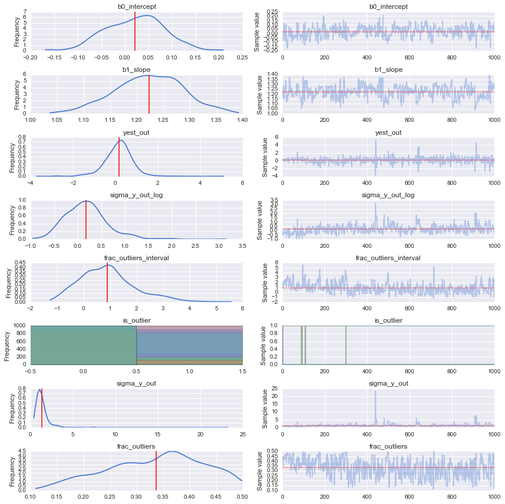

```python
_ = pm.traceplot(trc_signoise[-1000:], figsize=(12,len(trc_signoise.varnames)*1.5)
    ,lines={k: v['mean'] for k, v in pm.df_summary(trc_signoise[-1000:]).iterrows()})
```

# Declare Outliers and Compare Plots

At each step, each datapoint may be either an inlier or outlier. Hopefully they spend an unequal time in the states.

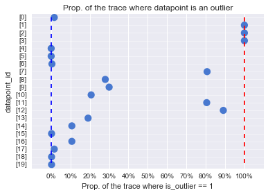

```python
plot_outlier_props(outlier_melt)
```

##### Declare outliers

**Note:**

- I will declare outliers to be datapoints that have value == 1 at the 5-percentile cutoff, i.e. in the percentiles from 5 up to 100, their values are 1.
- Try for yourself altering cutoff to larger values, which leads to an objective ranking of outlier-hood.

```python
cutoff = 5
dfhoggs['outlier'] = np.percentile(trc_signoise[-1000:]['is_outlier'],cutoff, axis=0)
dfhoggs['outlier'].value_counts()
```

```
0    17
1     3
Name: outlier, dtype: int64
```

## Posterior Prediction Plot

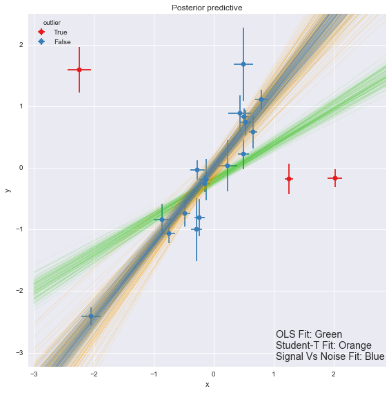

```python
plot_ppr(dfhoggs, trc_ols, trc_studentt, trc_signoise)
```

##### Observations

The posterior preditive fit for:

- the **OLS model** is shown in **Green** and as expected, it doesn't appear to fit the majority of our datapoints very well, skewed by outliers
- the **Robust Student-T model** is shown in **Orange** and does appear to fit the 'main axis' of datapoints quite well, ignoring outliers
- the **Robust Signal vs Noise model** is shown in **Blue** and also appears to fit the 'main axis' of datapoints rather well, ignoring outliers.

We see that the **Robust Signal vs Noise model** also yields specific estimates of *which* datapoints are outliers:

- 17 'inlier' datapoints, in **Blue** and
- 3 'outlier' datapoints shown in **Red**.
- From a simple visual inspection, the classification seems fair, and agrees with Jake Vanderplas' findings.

Overall, it seems that:

- the **Signal vs Noise model** behaves as promised, yielding a robust regression estimate and explicit labelling of inliers / outliers, but
- the **Signal vs Noise model** is quite complex and whilst the regression seems robust and stable, the actual inlier / outlier labelling seems slightly unstable
- if you simply want a robust regression without inlier / outlier labelling, the **Student-T model** may be a good compromise, offering a simple model, quick sampling, and a very similar estimate.

# Thank You

This content is available in the PYMC3 examples folder at http://pymc-devs.github.io/pymc3/GLM-robust-with-outlier-detection/

**Jonathan Sedar**  
Consulting Data Scientist  
Applied AI Ltd  
@jonsedar  
applied.ai

[figure not shown]